# Test with my data

# settings

```r
rm(list = ls())
library(tidyverse)
library(EMtree)
library(stringr)#added this
source("Jia_version.R")
```

In what follows I use my nestor::ggimage() function, which I came to really like when looking at networks. I give it to you, it is a simple heatmap function for ggplot, you can reorder lines if you whant to see a cluster pattern for example.

```r
ggimage<-function(data, no.names=FALSE, order=NULL){
  num=FALSE
  melted_data <- reshape2::melt(data)
  if(is.null(order)){p=ncol(data) ; order = 1:p}
 if(is.null(colnames(data))){
   level=1:p
   num=TRUE
   }else{level=colnames(data)}
  melted_data$Var1 <- factor( melted_data$Var1, levels = level[order])
  melted_data$Var2 <- factor( melted_data$Var2, levels = level[order])
  if(num){
    melted_data[,1:2]=apply(melted_data[,1:2],2, function(x) as.numeric(as.character(x)))
  }
  g=ggplot2::ggplot(melted_data, ggplot2::aes(x=.data$Var1, y=.data$Var2, fill=.data$value)) + ggplot2::theme_light()+
    ggplot2::labs(x="",y="")+ ggplot2::geom_tile() +ggplot2::guides(fill=FALSE)+
    ggplot2::theme(plot.title = ggplot2::element_text(size=10, hjust=0.5))+
    ggplot2::coord_fixed()
  if(no.names) g=g+theme(axis.text=element_blank(),axis.ticks =element_blank())
  g
}
```

# Tests

## Classic fit

```r
Y <- data.frame(read.csv("Y data.csv", header = TRUE))
dim(Y)
```

```
## [1]  12 105
```

```r
p <- ncol(Y)

X <- data.frame(read.csv("X data.csv", header = TRUE))
dim(X)
```

```
## [1] 12  2
```

When working with categorical variables, we have to specify a "design" matrix. An easy way to build one is to use model.matrix(), I should tell in the examples about that:

```r
# deal with covariates
built_covar_matrix=model.matrix(~X$Month+X$MBC)
head(built_covar_matrix)
```

```
##   (Intercept) X$MonthJune X$MonthMarch X$MonthSeptember    X$MBC
## 1           1           0            0                0 402.2798
## 2           1           0            0                0 462.5994
## 3           1           0            0                0 388.7918
## 4           1           1            0                0 571.9901
## 5           1           1            0                0 746.4315
## 6           1           1            0                0 766.1113
```

The classic_fit went right, I modified warnings so we don't see the "Nans produced" (they are useless).

```r
classic_fit <- new_ResampleEMtree(
  counts = Y,
  covar_matrix =built_covar_matrix,
  unlinked = NULL,
  S = 20,
  cores = 3,
  maxIter = 20
)
```

```
## Computing  20 probability matrices with 3 core(s)... 2.61 mins
```

About the threshold on the probabilities, it is set by the user and could be anything. However the way probabilities are computed, the mean of the matrix will always be 2/p, because the sum of all probabilities must be (p-1) (which is the number of edges in a spanning tree) and they are p(p-1)/2 possible edges. 2/p is the average value. Indeed in the example I added +0.1 to be more stringent.

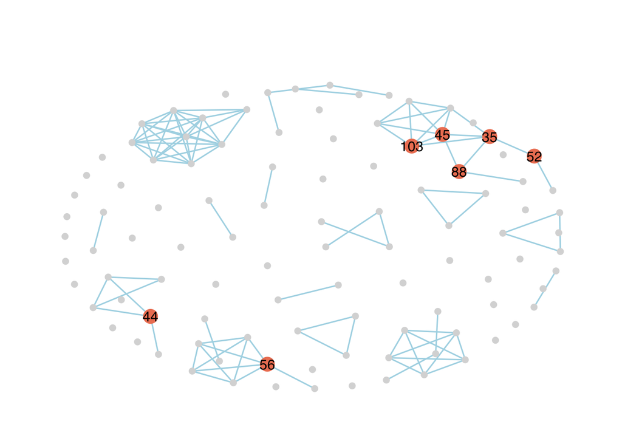

```r
Pt <- 2 / p

threshold_network <- (freq_selec(classic_fit$Pmat, Pt = Pt) > 0.8) * 1

draw_network(
  threshold_network,
  layout = "kk",
  btw_rank = 10,
  # nodes_label = 1:ncol(threshold_network),
  pal_nodes = c("grey85", "salmon2"),
  pal_edges = "lightblue"
)$G
```

```r
save_layout=ggraph::create_layout(threshold_network,"kk")

#ggimage(threshold_network)
```

## Unlinked fit

```r
# all plant column IDs
plant_ids <- (1:p)[str_detect(colnames(Y), pattern = "_")]
plant_ids
```

```
##  [1]  24  25  26  27  28  29  30  31  32  33  34  35  36  37  38  39  40  41  42
## [20]  43  44  45  46  47  48  49  50  51  52  53  54  55  56  57  58  59  60  61
## [39]  62  63  64  65  66  67  68  69  70  71  72  73  74  75  76  77  78  79  80
## [58]  81  82  83  84  85  86  87  88  89  90  91  92  93  94  95  96  97  98  99
## [77] 100 101 102 103 104 105
```

```r
# 24:105

test_unlinked <- plant_ids

# unlinked fit
unlink_fit1 <- new_ResampleEMtree(
  counts = Y,
  covar_matrix = built_covar_matrix,
  unlinked = test_unlinked,
  S = 20,
  cores = 3,
  maxIter = 20
)
```

```
## Computing  20 probability matrices with 3 core(s)... 2.04 mins
##  7  failed samples.
```

To make this work I revised the way unlinked nodes were specified throughout the optimization.

Constraining the algorithm make some sub-samples fail. I was expecting that, I am actually astonished that most of them converge fine with so many variables and so few data samples!

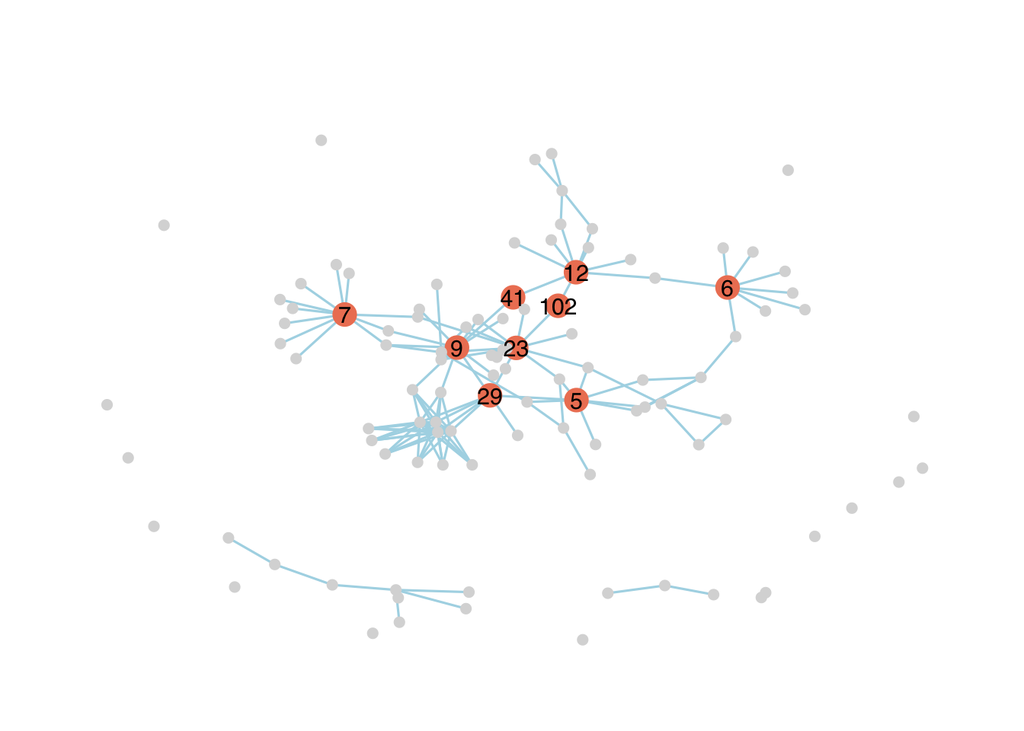

```r
threshold_network_unlinked <- (freq_selec(unlink_fit1$Pmat, Pt = Pt) > 0.8) * 1
draw_network(
  threshold_network_unlinked,
  layout = "kk",
  btw_rank = 10,
  # nodes_label = 1:ncol(threshold_network),
  pal_nodes = c("grey85", "salmon2"),
  pal_edges = "lightblue"
)$G
```

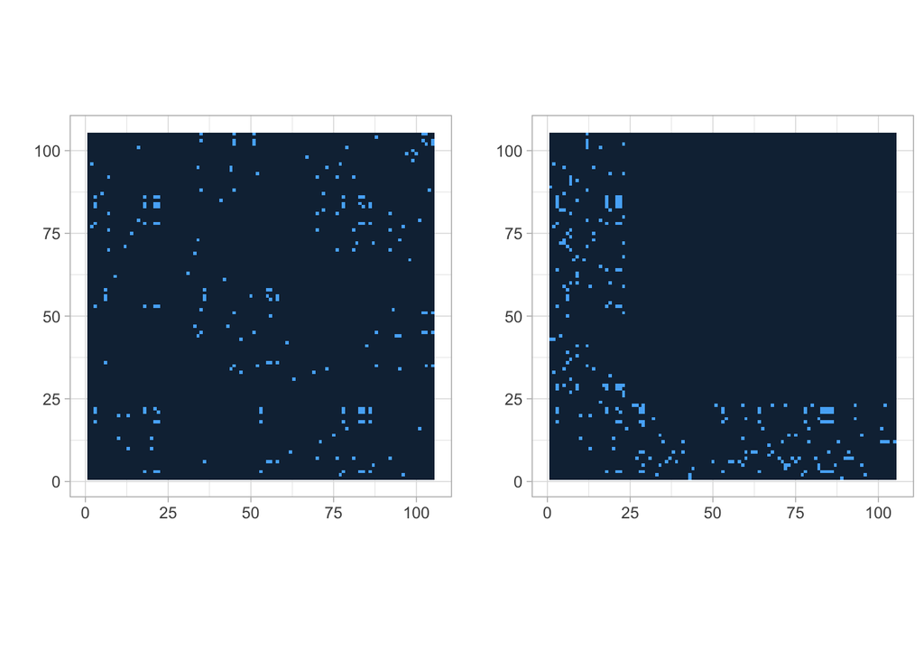

```r
gridExtra::grid.arrange(ggimage(threshold_network),ggimage(threshold_network_unlinked),ncol=2)
```

Unlinking the plants made new fauna-plant links appear! Hurray

# keep position

I notived you want to keep the nodes position from the first graph to the next with set.seed() and coord_fixed(). This won't work, I've been there :) If you update your EMtree package, you will find a new parameter of draw_network: stored_layout. This allows you to pass a layout previously computed with create_layout for example.

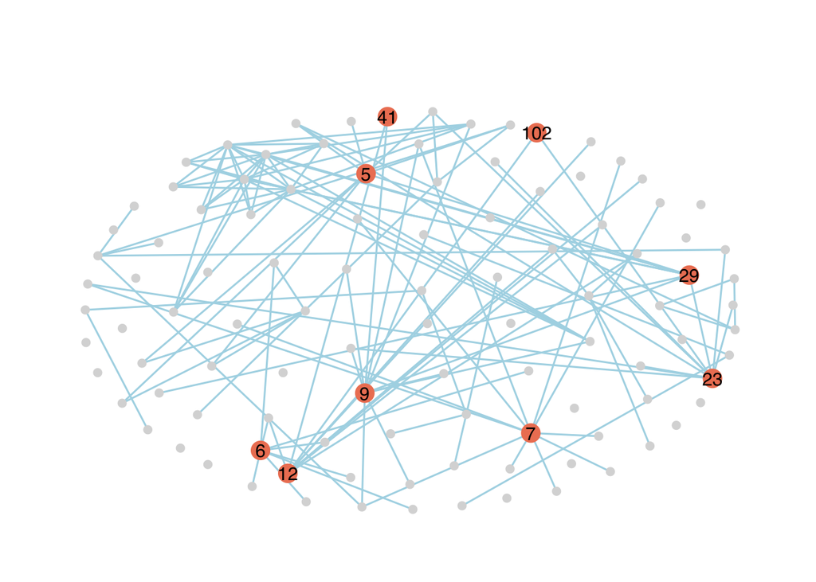

```r
save_layout=ggraph::create_layout(threshold_network,"kk")

draw_network(
  threshold_network_unlinked,
  stored_layout = save_layout, # no need to specify layout if a stored_layout is provided
  btw_rank = 10,
  pal_nodes = c("grey85", "salmon2"),
  pal_edges = "lightblue"
)$G
```